# 壹、研究動機

我們的研究動機源自一篇自由時報於2021年4月24日「缺水容易引發地震，中研院研究證實了」這篇報導，該篇報導指出中研院研究發現，台灣西部的地震頻率和地下水位有關，研究指出西部季節地震活動度在每年2月至4月達到峰值，在7月至9月下降到最低值，也就是說當面臨缺水時，更容易引發地震。於是我們循該篇報導所引用的內容，找到中研院地球科學研究員許雅儒於《Science Advances 》所發表的期刊，此期刊成為我們的理論基礎。

- 報導來源：https://news.ltn.com.tw/news/life/breakingnews/3510197
- 期刊來源：https://advances.sciencemag.org/content/7/16/eabf7282.full

# 貳、文獻回顧

閱讀《Synchronized and asynchronous modulation of seismicity by hydrological loading: A case study in Taiwan》後做出以下文獻探討：

### 一、資料處理

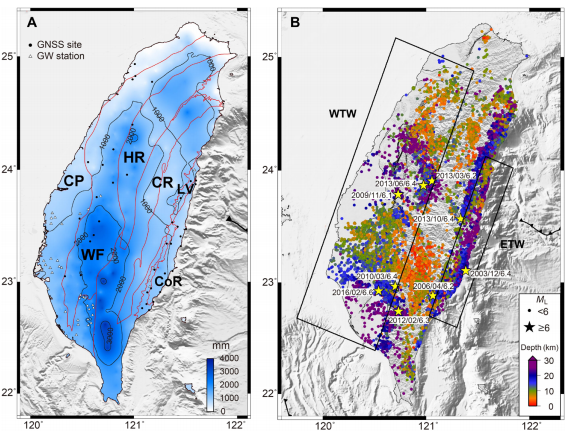

   ### 研究結論 **台灣西部地區地震與台灣陸地儲水量(=地下水位)**關係呈現**負相關**，枯水時期將導致地震頻率增加，但**台灣東部淺層地震活動度（<18 km）**和季節變化**沒有關聯**，也就是否枯水期並不會影響地震頻率，無法用流體在斷層帶的作用或孔隙液壓變化解釋其結果。

### 二、輔助理論

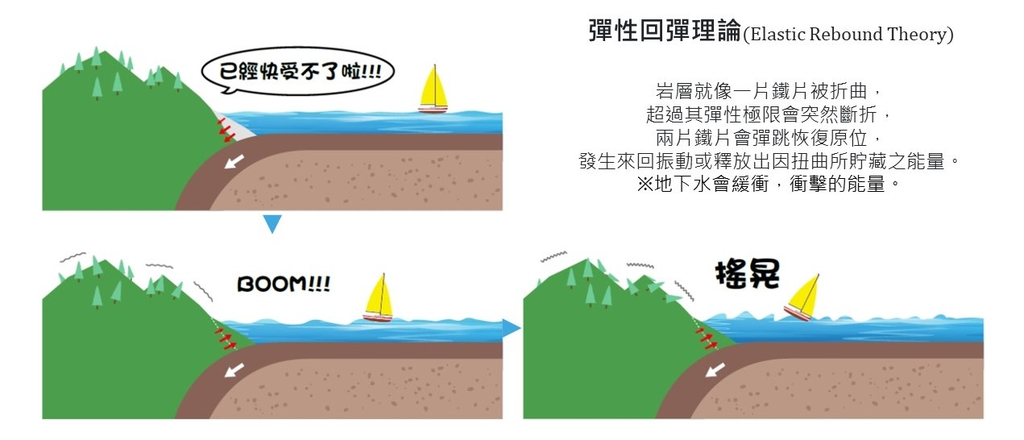

- 資料來源：https://scweb.cwb.gov.tw/zh-tw/guidance/faqdetail/10
- 礙於中央提供的地下水位資料需要購買才能取得，由於地下水位來自地表的降雨，於是本組好奇若使用雨量資料是否能做出一樣的結論，所以最終我們決定探討降水量與地震之間的關聯性。

# 參、分析方式

### 一、分析目標

1. 降水量及地震規模的關係
2. 降水量及地震頻率的關係

### 二、分析流程

1. 降水量及地震規模的關係  
   數據採用地震發生地在地震發生**前10日**的**累計降水量**及**地震規模**，並探討兩者間的線性關係。
2. 降水量及地震頻率的關係  
   數據採用**每月地區的平均降水量**及**每月地震發生頻率**，並探討兩者間的線性關係。

### 三、 和期刊異同處

1. 資料處理方式不同處：
   - 地下水位的資料 >>> **降水量**替代
   - 淺層地震沒有篩選
   - 地震震數據未篩除中央山脈的數據
2. 資料比對：
   - 新增：  
     地震規模和降水量之關係
   - 相同：  
     地震頻率和季節之關係  
     地震頻率和降水量之關係

# 肆、專題執行

## 一、資料集

### (一)、 地震活動彙總.csv

- 資料來源：中央氣象局 https://scweb.cwb.gov.tw/zh-tw/earthquake/data/
- 取得方式：手動抓
- 資料欄位：

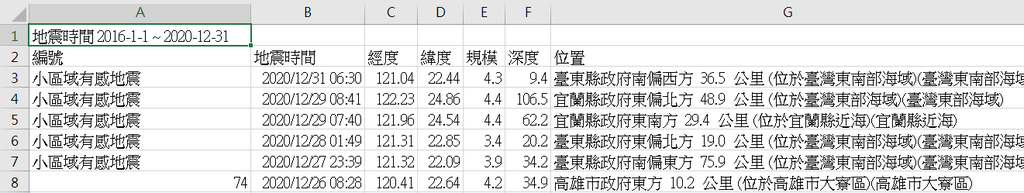

### (二)、現存觀測站資料

- 資料來源：中央氣象局 https://e-service.cwb.gov.tw/wdps/obs/state.htm
- 取得方式：網路爬蟲
- 資料欄位：

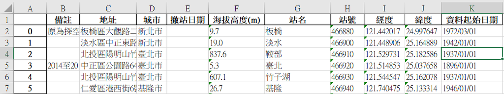

```python
# station_info_collect.py
#僅提供爬蟲code，不做演示

# library
import requests as re
import pandas as pd
from bs4 import BeautifulSoup

#建立資料寫入路徑
normal_path = "D\\Final_Project_Group3"

url = 'https://e-service.cwb.gov.tw/wdps/obs/state.htm'#中央氣象局觀測站資料
station_info = pd.DataFrame()#存放爬取的資料

#先抓取網頁資料
resp = re.get(url)
soup = BeautifulSoup(resp.content, 'xml')
infos = soup.find('div', {'id':'existing_station'}).findAll('tr', {'class':""})

writer = pd.ExcelWriter("現存觀測站資料.xlsx")

#分類每筆資料
for data in infos:
    df = {"站號":data.findAll('td')[0].text,
          "站名":data.findAll('td')[1].text,
          "海拔高度(m)":data.findAll('td')[2].text,
          "經度":data.findAll('td')[3].text,
          "緯度":data.findAll('td')[4].text,
          "城市":data.findAll('td')[5].text,
          "地址":data.findAll('td')[6].text,
          "資料起始日期":data.findAll('td')[7].text,
          "撤站日期":data.findAll('td')[8].text,
          "備註":data.findAll('td')[9].text}
    station_info = station_info.append(df, ignore_index=True)

#刪除只有雷達功能的測站：五分山雷達測站、墾丁雷達站
station_info = station_info.drop(index=[0,31]).reset_index(drop=True)

station_info.to_excel(writer)
writer.save()
```

### (三)、現存觀測站的觀測數據

```python
#僅提供爬蟲code，不做演示

#library
import requests as re
import pandas as pd
from bs4 import BeautifulSoup

#建立資料讀取路徑
normal_path = "D\\Final_Project_Group3"

#會利用第二個資料集—現存觀測站資料.xlsx中的站號欄位對網址進行索引值的替換
stat_info = pd.read_excel(normal_path+"現存觀測站資料.xlsx", usecols=["站名", "站號"])
```

### 1. 月資料weather_monthdata2015-2020

#### 以「測站代碼+測站名稱.xlsx」為檔名儲存在資料夾內

- 資料來源：中央氣象局 https://e-service.cwb.gov.tw/HistoryDataQuery/
- 取得方式：網路爬蟲
- 資料欄位：

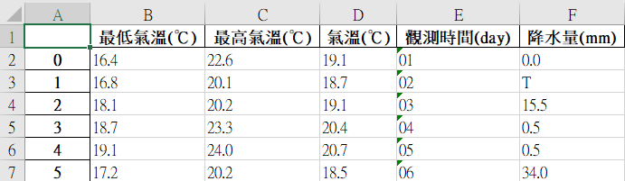

```python
# weather_monthdata_collect.py
#建立資料寫入路徑
monthdata_path = "D\\Final_Project_Group3\\weather_monthdata2015-2020\\" #事先建立好要存放的資料夾

#從查詢網址可以觀察到只要變換station及datapicker的部分就可以獲取欲查詢的測站及其月資料，所以會在迴圈中透過這兩個部分的變化進行爬蟲
url = "https://e-service.cwb.gov.tw/HistoryDataQuery/MonthDataController.do?command=viewMain&"

for index in range(len(stat_info)):
    filename = stat_info["站名"][index] + stat_info["站號"][index] + ".xlsx"
    writer = pd.ExcelWriter(monthdata_path+filename)
    for year in range(2015, 2021):
        for month in range(1,13):
            weather_info = pd.DataFrame()
            if month < 10:
                date = str(year) + "-0" + str(month)
            else:
                date = str(year) + "-" +str(month)
            stat_url = url + "station=" + stat_info["站號"][index] + "&stname=&datepicker=" + date
            try:
                session = re.session()
                resp = session.get(stat_url)
                soup = BeautifulSoup(resp.text, 'lxml')
                datas = soup.find('table', {'id':'MyTable'}).findAll('tr', {'class':''})
                for data in datas:
                    #只取出可能會用到的資料
                    df = {"觀測時間(day)":data.findAll('td')[0].text,
                          "氣溫(℃)":data.findAll('td')[7].text,
                          "最高氣溫(℃)":data.findAll('td')[8].text,
                          "最低氣溫(℃)":data.findAll('td')[10].text,
                          "降水量(mm)":data.findAll('td')[21].text}
                    weather_info = weather_info.append(df, ignore_index=True)
            except:
                pass
            #依照年-月進行分頁
            weather_info.to_excel(writer, sheet_name = date)
    writer.save()
#最後在weather_monthdata2015-2020呈現會是以「測站代碼+測站名稱.xlsx」為檔名的資料
#實際爬蟲時間大概一個測站是20秒
```

#### 以「測站代碼+測站名稱.xlsx」為檔名儲存在資料夾內

- 資料來源：中央氣象局 https://e-service.cwb.gov.tw/HistoryDataQuery/
- 取得方式：網路爬蟲
- 資料欄位：

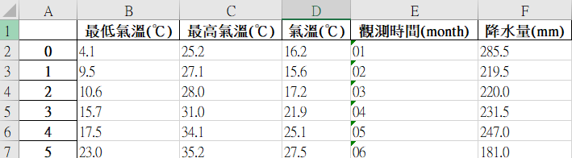

```python
# weather_yeardata_collect.py
#建立資料讀取及寫入路徑
yeardata_path = "D\\Final_Project_Group3\\weather_yeardata2016-2020\\" #事先建立好要存放的資料夾

#從查詢網址可以觀察到只要變換station及datapicker的部分就可以獲取欲查詢的測站及其年資料，所以會在迴圈中透過這兩個部分的變化進行爬蟲
url = "https://e-service.cwb.gov.tw/HistoryDataQuery/MonthDataController.do?command=viewMain&"

for index in range(len(stat_info)):
    filename = stat_info["站名"][index] + stat_info["站號"][index] + ".xlsx"
    writer = pd.ExcelWriter(yeardata_path+filename)
    for year in range(2016, 2021):
        weather_info = pd.DataFrame()
        stat_url = url + "station=" + stat_info["站號"][index] + "&stname=&datepicker=" + str(year)
        try:
            session = re.session()
            resp = session.get(stat_url)
            soup = BeautifulSoup(resp.text, 'lxml')
            datas = soup.find('table', {'id':'MyTable'}).findAll('tr', {'class':''})
            for data in datas:
                #只取出可能會用到的資料
                df = {"觀測時間(month)":data.findAll('td')[0].text,
                      "氣溫(℃)":data.findAll('td')[7].text,
                      "最高氣溫(℃)":data.findAll('td')[8].text,
                      "最低氣溫(℃)":data.findAll('td')[10].text,
                      "降水量(mm)":data.findAll('td')[18].text}
                weather_info = weather_info.append(df, ignore_index=True)
        except:
            pass
        #依照年進行分頁
        weather_info.to_excel(writer, sheet_name = str(year))
    writer.save()

#最後在weather_yeardata2016-2020呈現會是以「測站代碼+測站名稱.xlsx」為檔名的資料
#實際爬蟲時間大概一個測站是2秒
```

## 二、資料預處理

### (一)、 現存觀測站數據月資料及年資料

1. **欄位資料特殊符號轉換**：T表示微量(小於 0.1mm)，x表故障，&代表降水量資料累積於後，/表不明，…表無觀測。
2. 欄位格式的轉換

```python
#僅提供清理資料的code，不做演示

#library
import pandas as pd
import numpy as np

#建立資料讀取路徑
normal_path = "D:\\Final_Project_Group3\\"

#會利用現存觀測站資料.xlsx中的站號欄位進行檔名的替換
stat_info = pd.read_excel(normal_path+"現存觀測站資料.xlsx", usecols=["站名", "站號"])
```

### A.月資料清理

```python
# weather_monthdata_clear.py
#建立存放路徑及資料讀取路徑
monthdata_path = "D:\\Final_Project_Group3\\weather_monthdata2015-2020\\"
monthdata_clear_path = "D:\\Final_Project_Group3\\weather_monthdata2015-2020clear\\"

#開始清理檔案
for index in range(len(stat_info)):
    filename = stat_info["站名"][index] + stat_info["站號"][index] + ".xlsx"
    writer = pd.ExcelWriter(monthdata_path+filename)
    for year in range(2015, 2021):
        for month in range(1,13):
            if month < 10:
                sheet_name = str(year) + "-0" + str(month)
            else:
                sheet_name = str(year) + "-" +str(month)

            #從weather_monthdata2015-2020讀取
            weather_data = pd.read_excel(monthdata_path+filename, sheet_name=sheet_name, index_col=0)

            #T表示微量(小於 0.1mm)，x表故障，&代表降水量資料累積於後，/表不明，…表無觀測。
            weather_data = weather_data.replace("... ", np.NaN)
            weather_data = weather_data.replace("T ", 0)
            weather_data = weather_data.replace("X ", np.NaN)
            weather_data = weather_data.replace("& ", 0)
            weather_data = weather_data.replace("/ ", np.NaN)

            #轉換欄位格式
            weather_data['最低氣溫(℃)'] = weather_data['最低氣溫(℃)'].astype('float64')
            weather_data['最高氣溫(℃)'] = weather_data['最高氣溫(℃)'].astype('float64')
            weather_data['氣溫(℃)'] = weather_data['氣溫(℃)'].astype('float64')
            weather_data['降水量(mm)'] = weather_data['降水量(mm)'].astype('float64')

            #將清理過的資料存至weather_monthdata2015-2020clear這個資料夾
            weather_data.to_excel(writer, sheet_name=sheet_name)
    writer.save()
```

### B.年資料清理

```python
# weather_yeardata_clear.py
#建立存放路徑及資料讀取路徑
yeardata_path = "D:\\Final_Project_Group3\\weather_yeardata2016-2020\\"
yeardata_clear_path = "D:\\Final_Project_Group3\\weather_yeardata2016-2020clear\\"

#開始清理檔案
for index in range(len(stat_info)):
    filename = stat_info["站名"][index] + stat_info["站號"][index] + ".xlsx"
    writer = pd.ExcelWriter(yeardata_clear_path+filename)
    for year in range(2016, 2021):
        #從weather_yeardata2015-2020讀取
        weather_data = pd.read_excel(yeardata_path+filename, sheet_name=str(year), index_col=0)
        #T表示微量(小於 0.1mm)，x表故障，&代表降水量資料累積於後，/表不明，…表無觀測。
        weather_data = weather_data.replace("... ", np.NaN)
        weather_data = weather_data.replace("T ", 0)
        weather_data = weather_data.replace("X ", np.NaN)
        weather_data = weather_data.replace("& ", 0)
        weather_data = weather_data.replace("/ ", np.NaN)

        #轉換欄位格式
        weather_data['最低氣溫(℃)'] = weather_data['最低氣溫(℃)'].astype('float64')
        weather_data['最高氣溫(℃)'] = weather_data['最高氣溫(℃)'].astype('float64')
        weather_data['氣溫(℃)'] = weather_data['氣溫(℃)'].astype('float64')
        weather_data['降水量(mm)'] = weather_data['降水量(mm)'].astype('float64')

        #將清理過的資料存至weather_yeardata2016-2020clear這個資料夾
        weather_data.to_excel(writer, sheet_name=str(year))
    writer.save()
```

### (二)、觀測站及地震資料分東西部_地圖呈現

1. 透過QGIS按照東西部劃分**地震資料**並除*去離島地區*的資料，如下圖所示：

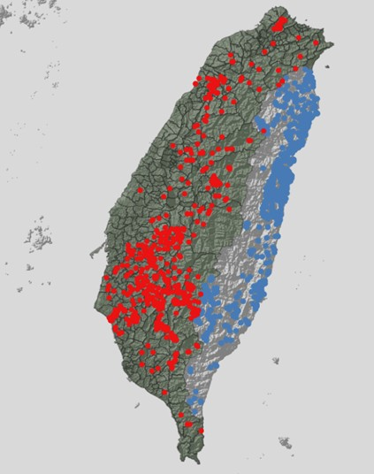

1. 透過QGIS按照東西部劃分**觀測站位置**資料並除*去離島地區*的資料，如下圖所示：

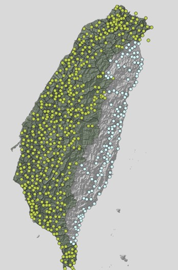

## 三、找出距離地震位置最近的觀測站，並算出地震發生前的累積降雨量

```python
# get_nearest.py
#library
import pandas as pd
from math import radians
from math import cos
from math import acos
from math import sin
from math import tan
from math import atan
from datetime import datetime as dt
from datetime import timedelta

#建立資料讀取及寫入路徑
normal_path = "D:\\Final_Project_Group3\\"

#所需資料
east_earthquake_file = "東部地震資料.csv"
west_earthquake_file = "西部地震資料.csv"
station_file = "現存觀測站資料.xlsx"

east_earthquake_data = pd.read_csv(normal_path+east_earthquake_file, encoding="big5")
west_earthquake_data = pd.read_csv(normal_path+west_earthquake_file, encoding="big5")
station_info = pd.read_excel(normal_path+station_file, index_col=0)

#後續將結果寫入新檔案
east_writer = pd.ExcelWriter(normal_path+"東部地震活動及最近測站.xlsx")
west_writer = pd.ExcelWriter(normal_path+"西部地震活動及最近測站.xlsx")
```

```python
#計算經緯距離
def getDistance(latA, lonA, latB, lonB):
    ra = 6378140  # radius of equator: meter
    rb = 6356755  # radius of polar: meter
    flatten = (ra - rb) / ra  # Partial rate of the earth
    # change angle to radians
    radLatA = radians(latA)
    radLonA = radians(lonA)
    radLatB = radians(latB)
    radLonB = radians(lonB)
    pA = atan(rb / ra * tan(radLatA))
    pB = atan(rb / ra * tan(radLatB))
    x = acos(sin(pA) * sin(pB) + cos(pA) * cos(pB) * cos(radLonA - radLonB))
    c1 = (sin(x) - x) * (sin(pA) + sin(pB))**2 / cos(x / 2)**2
    c2 = (sin(x) + x) * (sin(pA) - sin(pB))**2 / sin(x / 2)**2
    dr = flatten / 8 * (c1 - c2)
    distance = round(ra * (x + dr), 2)
    return distance
```

```python
#判斷地震發生往前回推的時間是否晚於測站啟用時間
def date_cal(earthquake_time, station_start_date, days):
    delta = timedelta(days = days)
    date_traceback = earthquake_time - delta
    return date_traceback > station_start_date
```

```python
#將最近且數據完整的測站紀錄於的新欄位最近站名、最近站號
def getNearest(earthquake_data):
    #排除規模小於2.5的部分
    filter1 = (earthquake_data["規模"] > 2.5)
    new_earthquake_data = earthquake_data[filter1].reset_index(drop=True)
    new_earthquake_data["最近站名"] = ""
    new_earthquake_data["最近站號"] = ""
    new_earthquake_data["距離(m)"] = 0.00
    for earthquake_index in range(len(new_earthquake_data)):
        eq_stat_distance = pd.DataFrame()
        latA = new_earthquake_data["緯度"][earthquake_index]
        lonA = new_earthquake_data["經度"][earthquake_index]
        earthquake_time = dt.strptime(new_earthquake_data["地震時間"][earthquake_index], "%Y/%m/%d %H:%M").date()
        for station_index in range(len(station_info)):
            latB = station_info["緯度"][station_index]
            lonB = station_info["經度"][station_index]
            station_start_date = dt.strptime(station_info["資料起始日期"][station_index], "%Y/%m/%d").date()
            distance = getDistance(latA, lonA, latB, lonB)
            df = {"站名":station_info["站名"][station_index],
                  "站號":station_info["站號"][station_index],
                  "距離(m)":distance,
                  "啟用日期":station_start_date}
            eq_stat_distance = eq_stat_distance.append(df, ignore_index=True)
        #按照距離遠近進行排序
        eq_stat_distance = eq_stat_distance.sort_values(by=["距離(m)"]).reset_index(drop=True)
        for station_index in range(len(eq_stat_distance)):
            station_start_date = eq_stat_distance["啟用日期"][station_index]
            if date_cal(earthquake_time, station_start_date, days):
                #將符合所需條件的測站紀錄至new_earthquake_data
                new_earthquake_data["最近站名"][earthquake_index] = eq_stat_distance["站名"][station_index]
                new_earthquake_data["最近站號"][earthquake_index] = eq_stat_distance["站號"][station_index]
                new_earthquake_data["距離(m)"][earthquake_index] = eq_stat_distance["距離(m)"][station_index]
                break
    return new_earthquake_data
```

```python
#可選擇要回推累積降雨量的天數，若不設定即days=10
days = int(input("請輸入欲回推的天數："))
if days == "":
    days = 10

#記錄各地震活動及其最近測站並另存檔案以利計算累積降雨量
east_earthquake_data = getNearest(east_earthquake_data)
west_earthquake_data = getNearest(west_earthquake_data)

east_earthquake_data.to_excel(east_writer)
west_earthquake_data.to_excel(west_writer)

east_writer.save()
west_writer.save()
```

#### 東部地震活動及最近測站.xlsx

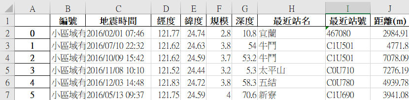

#### 西部地震活動及最近測站.xlsx

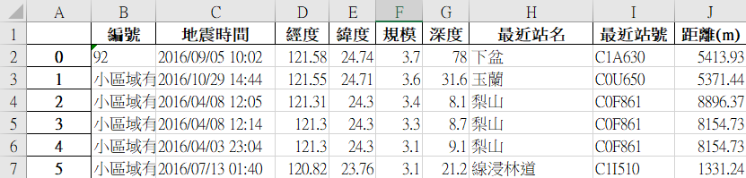

```python
# earthquake_rainfall_calcu.py
#建立氣象資料讀取路徑
weather_data_path = "D:\\Final_Project_Group3\\weather_monthdata2015-2020clear\\"

#所需資料
east_earthquake_data = pd.read_excel(normal_path+"東部地震活動及最近測站.xlsx") #第三部分匯出的檔案
west_earthquake_data = pd.read_excel(normal_path+"西部地震活動及最近測站.xlsx") #第三部分匯出的檔案

east_writer = pd.ExcelWriter("東部地震及降水量.xlsx")
west_writer = pd.ExcelWriter("西部地震及降水量.xlsx")
```

```python
#計算地震發生前累積降水量
def raifall_calcu(earthquake_data, days):
    result_data = pd.DataFrame()
    for index in range(len(earthquake_data)):
        rainfall_collect = 0
        rainfall_file = earthquake_data["最近站名"][index] + earthquake_data["最近站號"][index] + ".xlsx"
        time = dt.strptime(earthquake_data["地震時間"][index], "%Y/%m/%d %H:%M").date()

        for delta in range(days): #不排除地震當天的降雨，並往前推指定天數
            delta = timedelta(days = delta)
            rainfall_day = time - delta
            #讀取氣象資料
            if rainfall_day.month < 10:
                sheet_name = str(rainfall_day.year) + "-0" + str(rainfall_day.month)
            else:
                sheet_name = str(rainfall_day.year) + "-" + str(rainfall_day.month)
            rainfall_data = pd.read_excel(weather_data_path+rainfall_file, sheet_name=sheet_name)
            rainfall_collect = np.append(rainfall_collect, rainfall_data["降水量(mm)"][rainfall_day.day-1])
        rainfall_accumu = round(np.nansum(rainfall_collect), 2) #計算累積降水量

        df = {"編號": earthquake_data["編號"][index],
              "地震時間":earthquake_data["地震時間"][index],
              "地震規模":earthquake_data["規模"][index],
              "累積降水量": rainfall_accumu,
              "測站站名": earthquake_data["最近站名"][index],
              "測站站號": earthquake_data["最近站號"][index],
              "與測站距離(m)": earthquake_data["距離(m)"][index]}
        result_data = result_data.append(df, ignore_index = True)
    return result_data
```

```python
#輸出結果
result_east_data = raifall_calcu(east_earthquake_data, days)
result_west_data = raifall_calcu(west_earthquake_data, days)

result_east_data.to_excel(east_writer)
result_west_data.to_excel(west_writer)

east_writer.save()
west_writer.save()
```

#### 東部地震及降水量.xlsx

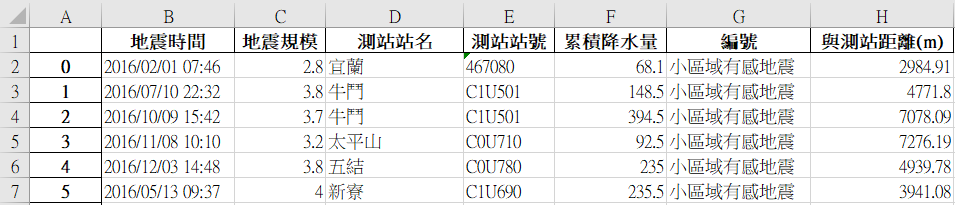

#### 西部地震及降水量.xlsx

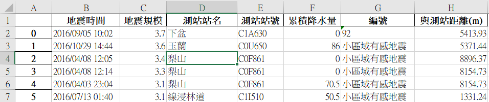

## 小結

這部分主要是想看地震規模以及地震發生前的降水量兩者關係

## 四、地震頻率與當月平均月雨量

```python
# earthquake_frequency.py
#library
import pandas as pd
import numpy as np
from datetime import datetime as dt

#建立資料寫入及讀取路徑
normal_path = "D:\\Final_Project_Group3\\"
weather_data_path = "D:\\Final_Project_Group3\\weather_yeardata2016-2020clear\\"

east_earthquake = pd.read_csv(normal_path+"東部地震資料.csv", encoding="big5")
west_earthquake = pd.read_csv(normal_path+"西部地震資料.csv", encoding="big5")

east_station = pd.read_excel(normal_path+"西部觀測站資料.xlsx")
west_station = pd.read_excel(normal_path+"東部觀測站資料.xlsx")

#後須將結果寫入新檔案
east_writer = pd.ExcelWriter(normal_path + "東部地震頻率及平均降水量.xlsx")
west_writer = pd.ExcelWriter(normal_path + "西部地震頻率及平均降水量.xlsx")
```

```python
#計算每月的地震頻率
def earthquake_frequency(earthquake_data):
    #排除規模小於2.5的部分
    filter1 = (earthquake_data["規模"] > 2.5)
    new_earthquake_data = earthquake_data[filter1].reset_index(drop=True)
    frequency = {}
    for index in range(len(new_earthquake_data[filter1])):
        time = dt.strptime(new_earthquake_data["地震時間"][index], "%Y/%m/%d %H:%M").date()
        year = str(time.year)
        if time.month < 10:
            month = "0" + str(time.month)
        else:
            month = str(time.month)
        frequency[year+"/"+month] = frequency.setdefault(year+"/"+month, 0) + 1
    return list(frequency.items())
```

```python
#計算每月的平均降水量
def rainfall_ave(station_info, year, month):
    rainfall_collect = []
    for index in range(len(station_info)):
        station_name = station_info["站名"][index]
        station_code = str(station_info["站號"][index])
        file = station_name + station_code + ".xlsx"
        data = pd.read_excel(weather_data_path+file, sheet_name = str(year))
        rainfall = data["降水量(mm)"][month-1]
        rainfall_collect = np.append(rainfall_collect, rainfall)
    return round(np.nanmean(rainfall_collect), 2)
```

```python
#計算指定區域每月的平均降水量
def raifall_everymonth(earthquake_frequency, station_info):
    for index in range(len(earthquake_frequency)):
        time = dt.strptime(earthquake_frequency["時間(年月)"][index], "%Y/%m").date()
        year = time.year
        month = time.month
        earthquake_frequency["平均降水量(mm)"][index] = rainfall_ave(station_info, year, month)
```

```python
#先計算地震頻率部分
east_relation = pd.DataFrame(earthquake_frequency(east_earthquake), columns=["時間(年月)", "地震頻率(次)"])
west_relation = pd.DataFrame(earthquake_frequency(west_earthquake), columns=["時間(年月)", "地震頻率(次)"])

#先建立平均降水量的欄位
east_relation["平均降水量(mm)"] = 0.00
west_relation["平均降水量(mm)"] = 0.00

#開始蒐集每月的平均降水量
raifall_everymonth(east_relation, east_station)
raifall_everymonth(west_relation, west_station)

#寫入檔案
east_relation.to_excel(east_writer)
west_relation.to_excel(west_writer)

east_writer.save()
west_writer.save()
```

#### 東部地震頻率及平均降水量.xlsx

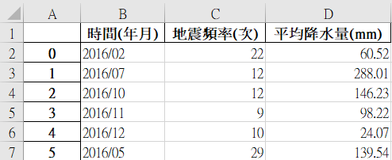

#### 西部地震頻率及平均降水量.xlsx

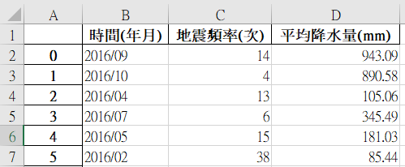

## 小結

這部分主要是為得出地震頻率以及每月平均降水量的數據

# 伍、結果分析

## 一、西部

1. 累積降水量(地震回推前10天的累積雨量)和地震規模
2. 平均降水量(月平均雨量)和地震頻率
3. 季節性(枯水期和豐水期)和地震頻率  
   ### A.累積降水量和地震規模之關係

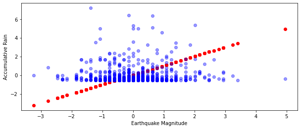

- 結果雖然顯示：累積降水量和地震規模呈現**正向關係**，但是**線性關係不顯著**，**顯著值 = 0.282801156 > 0.05顯著水準**。

### B.平均降水量和地震頻率之關係

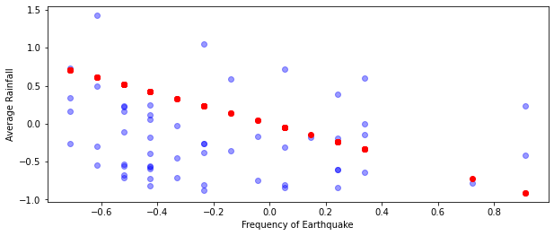

- 雖然西部平均雨量與地震頻率呈現**負相關**，(雨量越高，地震越少，與期刊結論相同)。紅色線可看出呈現負相關，雨量對地下水位為間接影響，且西部地震多為淺層地震(2016-2020年間只有4起深度地震)，水可調節地震活動。  
  但是**顯著值 = 0.86914777 > 0.05顯著水準**，**線性關係不顯著**，這部分可能是因為我們用的降水量是流量，而期刊所選用的地下水位是存量所造成的差異。

### C.季節性和地震頻率之關係

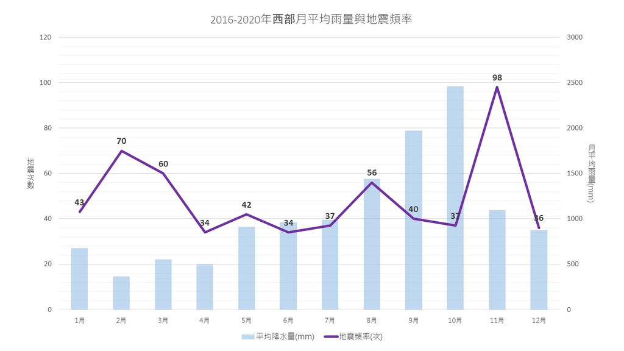

## 二、東部

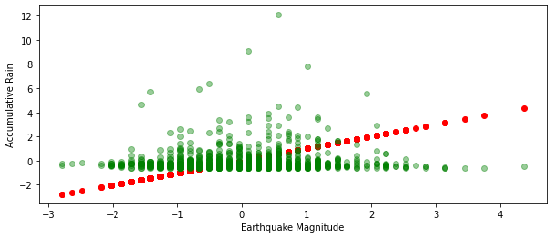

- 雖然結果顯示 累積降水量和地震規模呈現**正向關係**，但是**顯著值 = 0.096562825 > 0.05顯著水準**，**線性關係不顯著**。

### B.平均降水量和地震頻率之關係

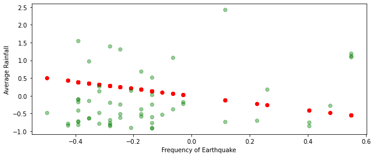

- 雖然東部平均雨量與地震頻率也是呈現負相關， 但是**顯著值 = 0.963364518 > 0.05顯著水準**，**線性關係不顯著**，一方面是我們使用流量，而期刊選用的是存量，造成差異，一方面也是，東部位於板塊交界帶，變因相對西部又更為錯綜複雜，誤打誤撞和期刊結果相同

### C.東部季節性和地震頻率之關係

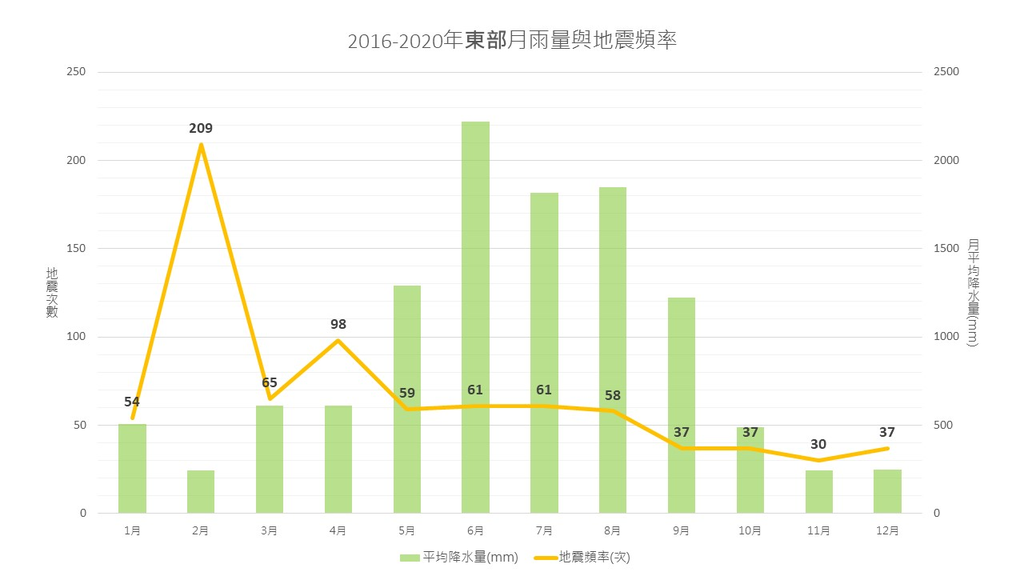

- 和西部相比可以東部的季節性和地震頻率沒有直接的關係。我們評估原因主要是期刊內容是刪除中央山脈的地震數據，我們並沒有排除該些數據，使得研究變因難以預測，造成結果的偏差。